# Running CAPM for all DJIA components

CA09 - Data Analytics for Finance

2021-10-06

We will get a list for all of the [Dow Jones Industrial Average (DJIA)](https://en.wikipedia.org/wiki/Dow_Jones_Industrial_Average) stocks and their ticker symbols and download some data. Besides the thirty stocks that make up the DJIA, we will also add `SPY` which is an SP500 ETF (Exchange Traded Fund).

# Scrape wikipedia to get stock market symbols (tickers)

```r
djia_url <- "https://en.wikipedia.org/wiki/Dow_Jones_Industrial_Average"

#get tables that exist on URL
tables <- djia_url %>%
  read_html() %>%
  html_nodes(css="table")


# parse HTML tables into a dataframe called djia.
# Use purr::map() to create a list of all tables in URL
djia <- map(tables, . %>%
               html_table(fill=TRUE)%>%
               clean_names())


# constituents
table1 <- djia[[2]] %>% # the second table on the page contains the ticker symbols
  mutate(date_added = ymd(date_added),

         # if a stock is listed on NYSE, its symbol is, e.g., NYSE: MMM
         # We will get prices from yahoo finance which requires just the ticker

         # if symbol contains "NYSE*", the * being a wildcard
         # then we jsut drop the first 6 characters in that string
         ticker = ifelse(str_detect(symbol, "NYSE*"),
                          str_sub(symbol,7,11),
                          symbol)
         )

# we need a vector of strings with just the 30 tickers + SPY
tickers <- table1 %>%
  select(ticker) %>%
  pull()  # pull() gets them as a sting of characters
```

# Download adjusted closing prices for all DJIA stocks

```r
# Notice the cache=TRUE argument in the chunk options. Because getting data is time consuming, # cache=TRUE means that once it downloads data, the chunk will not run again next time you knit your Rmd

starting_date <- Sys.Date() - 365*5 # go back 5 years from today; otherwise, give starting date as "2017-01-01"
ending_date <- Sys.Date()

myStocks <- tickers %>%
  tq_get(get  = "stock.prices",
         from = starting_date, # go back 5 years from today; otherwise, give starting date as "2017-01-01"
         to = ending_date
         ) %>%
  group_by(symbol)

# get prices for SPY, the SP500 ETF
spy <- tq_get("SPY", get  = "stock.prices",
              from = starting_date,
              to = ending_date
              )

glimpse(myStocks) # examine the structure of the resulting data frame
```

```
## Rows: 37,096
## Columns: 8
## Groups: symbol [30]
## $ symbol   <chr> "MMM", "MMM", "MMM", "MMM", "MMM", "MMM", "MMM", "MMM", "MMM"~
## $ date     <date> 2016-10-07, 2016-10-10, 2016-10-11, 2016-10-12, 2016-10-13, ~
## $ open     <dbl> 172, 172, 170, 170, 169, 171, 171, 172, 171, 170, 168, 173, 1~
## $ high     <dbl> 172, 173, 170, 170, 170, 171, 171, 172, 171, 170, 170, 173, 1~
## $ low      <dbl> 170, 171, 169, 169, 168, 170, 170, 170, 170, 169, 168, 171, 1~
## $ close    <dbl> 171, 171, 170, 170, 170, 170, 170, 170, 170, 170, 170, 171, 1~
## $ volume   <dbl> 2249100, 1936600, 1998700, 1554100, 1919700, 1512400, 1229200~
## $ adjusted <dbl> 148, 148, 146, 146, 147, 147, 147, 146, 146, 146, 146, 148, 1~
```

For each ticker symbol, the data frame contains its `symbol`, the `date`, the prices for `open`,`high`, `low` and `close`, and the `volume`, or how many stocks were traded on that day. More importantly, the data frame contains the `adjusted` closing price, which adjusts for any stock splits and/or dividends paid and this is what we will be using for our analyses.

# Calculate monthly returns

Financial performance and CAPM analysis depend on **returns** and not on **adjusted closing prices**. If I buy a stock today for 100 and I sell it tomorrow for 101.75, my one-day return, assuming no transaction costs, is 1.75%. So given the adjusted closing prices, our first step is to calculate daily and monthly returns.

```r
#calculate monthly  returns for the 30 DJIA stocks
myStocks_returns_monthly <- myStocks %>%
  tq_transmute(select     = adjusted,
               mutate_fun = periodReturn,
               period     = "monthly",
               type       = "arithmetic",
               col_rename = "monthly_return",
               cols = c(nested.col))


#calculate SPY monthly  returns
spy_returns_monthly <- spy %>%
  tq_transmute(select     = adjusted,
               mutate_fun = periodReturn,
               period     = "monthly",
               type       = "arithmetic",
               col_rename = "SPY_return",
               cols = c(nested.col))

DJIA_data <- left_join(myStocks_returns_monthly, spy_returns_monthly, by="date")
```

# `purr::map()` to run 30 regressions to estimate betas of all 30 DJIA stocks

```r
many_models <- DJIA_data %>%
  # create a dataframe containing a separate dataframe for each stock
  group_by(symbol) %>%
  nest()  %>%

  # Run a simple regression model for every stock in the dataframe
  mutate(simple_capm_model = data %>%
           map(~lm(monthly_return ~  SPY_return, data = .))) %>%

  # extract coefficients and model details with broom::tidy
  mutate(coefs = simple_capm_model %>%
           map(~ tidy(., conf.int = TRUE)),
         details = simple_capm_model %>% map(glance)) %>%
  ungroup()

# pull intercepts, or alphas
intercepts <-
  many_models %>%
  unnest(coefs) %>%
  filter(term == "(Intercept)") %>%
  arrange(estimate) %>%
  mutate(symbol = fct_inorder(symbol)) %>%
  select(symbol, estimate, std.error, conf.low, conf.high)

# let us look at the intercepts, or alphas
intercepts %>%
  rename(alpha = estimate) %>%
  kable()%>%
  kable_styling(bootstrap_options = c("striped", "hover", "condensed"))
```

| symbol | alpha | std.error | conf.low | conf.high |
| --- | --- | --- | --- | --- |
| DOW | -0.013 | 0.012 | -0.038 | 0.011 |
| IBM | -0.012 | 0.006 | -0.024 | 0.000 |
| CVX | -0.010 | 0.008 | -0.026 | 0.006 |
| WBA | -0.010 | 0.010 | -0.031 | 0.011 |
| MMM | -0.009 | 0.006 | -0.020 | 0.002 |
| BA | -0.005 | 0.014 | -0.032 | 0.023 |
| DIS | -0.003 | 0.008 | -0.018 | 0.013 |
| GS | -0.003 | 0.008 | -0.018 | 0.013 |
| TRV | -0.002 | 0.006 | -0.014 | 0.010 |
| JNJ | -0.002 | 0.005 | -0.012 | 0.008 |
| KO | -0.001 | 0.005 | -0.012 | 0.009 |
| AMGN | -0.001 | 0.008 | -0.018 | 0.015 |
| VZ | -0.001 | 0.005 | -0.011 | 0.010 |
| HON | -0.001 | 0.005 | -0.010 | 0.009 |
| CSCO | 0.001 | 0.007 | -0.014 | 0.016 |
| INTC | 0.002 | 0.009 | -0.016 | 0.020 |
| JPM | 0.003 | 0.007 | -0.010 | 0.016 |
| MRK | 0.003 | 0.007 | -0.010 | 0.016 |
| AXP | 0.004 | 0.006 | -0.009 | 0.016 |
| PG | 0.004 | 0.005 | -0.006 | 0.015 |
| CAT | 0.004 | 0.008 | -0.012 | 0.021 |
| V | 0.005 | 0.005 | -0.006 | 0.016 |
| HD | 0.005 | 0.006 | -0.006 | 0.017 |
| MCD | 0.007 | 0.006 | -0.004 | 0.019 |
| WMT | 0.008 | 0.006 | -0.005 | 0.020 |
| NKE | 0.008 | 0.007 | -0.007 | 0.023 |
| UNH | 0.010 | 0.007 | -0.004 | 0.023 |
| CRM | 0.011 | 0.009 | -0.007 | 0.029 |
| AAPL | 0.014 | 0.009 | -0.004 | 0.032 |
| MSFT | 0.018 | 0.005 | 0.009 | 0.027 |

```r
# pull slopes, or betas
slopes <- many_models %>%
  unnest(coefs) %>%
  filter(term == "SPY_return") %>%
  arrange(estimate) %>%
  mutate(symbol = fct_inorder(symbol)) %>%
  select(symbol, estimate, std.error, conf.low, conf.high)

# let us look at the betas, or measure of market risk
slopes %>%
  rename(beta = estimate) %>%
  kable()%>%
  kable_styling(bootstrap_options = c("striped", "hover", "condensed"))
```

| symbol | beta | std.error | conf.low | conf.high |
| --- | --- | --- | --- | --- |
| MRK | 0.396 | 0.145 | 0.105 | 0.686 |
| PG | 0.437 | 0.121 | 0.195 | 0.679 |
| VZ | 0.460 | 0.120 | 0.219 | 0.700 |
| WMT | 0.481 | 0.140 | 0.202 | 0.761 |
| WBA | 0.515 | 0.232 | 0.051 | 0.978 |
| INTC | 0.594 | 0.203 | 0.188 | 1.000 |
| MCD | 0.608 | 0.123 | 0.362 | 0.854 |
| KO | 0.639 | 0.115 | 0.408 | 0.870 |
| AMGN | 0.681 | 0.183 | 0.314 | 1.048 |
| JNJ | 0.728 | 0.111 | 0.506 | 0.951 |
| TRV | 0.762 | 0.133 | 0.496 | 1.027 |
| UNH | 0.788 | 0.152 | 0.483 | 1.093 |
| MSFT | 0.806 | 0.101 | 0.605 | 1.008 |
| NKE | 0.902 | 0.163 | 0.575 | 1.228 |
| CSCO | 0.945 | 0.166 | 0.613 | 1.276 |
| CAT | 0.951 | 0.187 | 0.577 | 1.324 |
| V | 0.981 | 0.121 | 0.738 | 1.223 |
| MMM | 0.983 | 0.126 | 0.731 | 1.235 |
| HD | 0.998 | 0.129 | 0.740 | 1.256 |
| CRM | 1.044 | 0.200 | 0.644 | 1.444 |
| HON | 1.165 | 0.104 | 0.958 | 1.373 |
| JPM | 1.182 | 0.147 | 0.887 | 1.476 |
| IBM | 1.201 | 0.135 | 0.930 | 1.471 |
| DIS | 1.205 | 0.175 | 0.854 | 1.556 |
| AAPL | 1.233 | 0.196 | 0.840 | 1.626 |
| AXP | 1.241 | 0.143 | 0.955 | 1.528 |
| CVX | 1.266 | 0.178 | 0.910 | 1.622 |
| GS | 1.529 | 0.176 | 1.177 | 1.882 |
| BA | 1.590 | 0.308 | 0.974 | 2.207 |
| DOW | 1.740 | 0.228 | 1.275 | 2.205 |

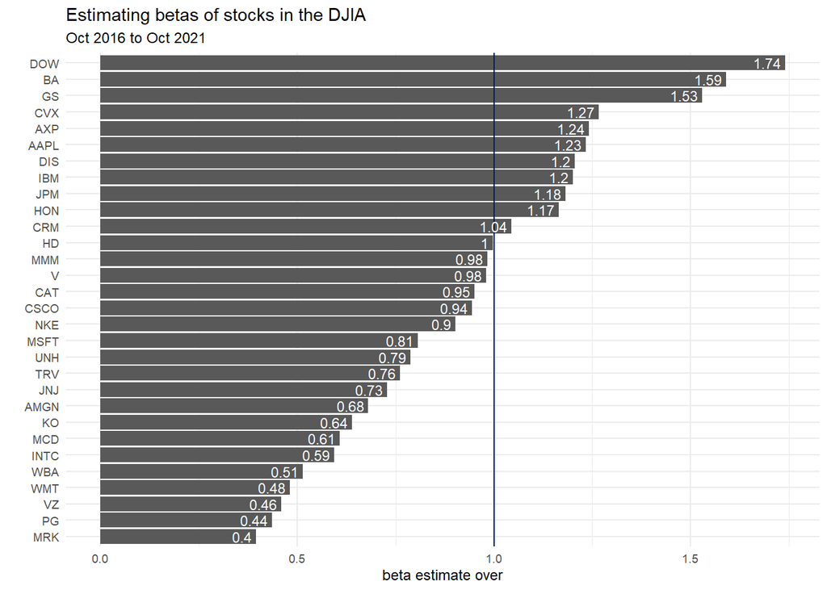

```r
# plot betas
ggplot(data = slopes, aes(x = symbol, y = estimate))+
  geom_col()+
  coord_flip()+
  theme_minimal(9)+
  labs(title = 'Estimating betas of stocks in the DJIA',
       subtitle = paste0(zoo::as.yearmon(starting_date), " to ", zoo::as.yearmon(ending_date)),
       x = "",
       y = "beta estimate over") +
  geom_hline(yintercept = 1, colour= "#001e62")+
  geom_label(aes(x = symbol, y = estimate, label = round(estimate, 2)),
             hjust = 1,
             vjust = 0.5,
             colour = "white",
             fill = NA,
             label.size = NA,
             family="Helvetica",
             size = 3)+
  NULL
```

```r
# pull R^2 and regression SE, or specific risk
rsq_errors <- many_models %>%
  unnest(details) %>%
  select(symbol, r.squared, sigma) %>%
  arrange(desc(r.squared))

# let us join everything together
capm_results <- inner_join(slopes, intercepts, by="symbol")
# Column `symbol` joining factors with different levels, coercing to character vector
capm_results <- inner_join(capm_results, rsq_errors, by="symbol")


# rename and keep beta, se(beta), and CI for beta, alpha, rsq, regression SE (specific risk)
capm_results <- capm_results %>%
  rename(
    beta = estimate.x,
    se_beta = std.error.x,
    beta_low = conf.low.x,
    beta_high = conf.high.x,
    alpha = estimate.y,
    residual_se = sigma) %>%
  select(symbol, beta, se_beta, beta_low, beta_high, alpha, r.squared, residual_se)


capm_results %>%
  arrange(desc(beta)) %>%
  kable()%>%
  kable_styling(bootstrap_options = c("striped", "hover", "condensed"))
```

| symbol | beta | se_beta | beta_low | beta_high | alpha | r.squared | residual_se |
| --- | --- | --- | --- | --- | --- | --- | --- |
| DOW | 1.740 | 0.228 | 1.275 | 2.205 | -0.013 | 0.661 | 0.064 |
| BA | 1.590 | 0.308 | 0.974 | 2.207 | -0.005 | 0.311 | 0.103 |
| GS | 1.529 | 0.176 | 1.177 | 1.882 | -0.003 | 0.561 | 0.059 |
| CVX | 1.266 | 0.178 | 0.910 | 1.622 | -0.010 | 0.462 | 0.059 |
| AXP | 1.241 | 0.143 | 0.955 | 1.528 | 0.004 | 0.560 | 0.048 |
| AAPL | 1.233 | 0.196 | 0.840 | 1.626 | 0.014 | 0.401 | 0.066 |
| DIS | 1.205 | 0.175 | 0.854 | 1.556 | -0.003 | 0.444 | 0.059 |
| IBM | 1.201 | 0.135 | 0.930 | 1.471 | -0.012 | 0.571 | 0.045 |
| JPM | 1.182 | 0.147 | 0.887 | 1.476 | 0.003 | 0.522 | 0.049 |
| HON | 1.165 | 0.104 | 0.958 | 1.373 | -0.001 | 0.682 | 0.035 |
| CRM | 1.044 | 0.200 | 0.644 | 1.444 | 0.011 | 0.316 | 0.067 |
| HD | 0.998 | 0.129 | 0.740 | 1.256 | 0.005 | 0.504 | 0.043 |
| MMM | 0.983 | 0.126 | 0.731 | 1.235 | -0.009 | 0.508 | 0.042 |
| V | 0.981 | 0.121 | 0.738 | 1.223 | 0.005 | 0.526 | 0.041 |
| CAT | 0.951 | 0.187 | 0.577 | 1.324 | 0.004 | 0.306 | 0.062 |
| CSCO | 0.945 | 0.166 | 0.613 | 1.276 | 0.001 | 0.355 | 0.055 |
| NKE | 0.902 | 0.163 | 0.575 | 1.228 | 0.008 | 0.341 | 0.055 |
| MSFT | 0.806 | 0.101 | 0.605 | 1.008 | 0.018 | 0.521 | 0.034 |
| UNH | 0.788 | 0.152 | 0.483 | 1.093 | 0.010 | 0.312 | 0.051 |
| TRV | 0.762 | 0.133 | 0.496 | 1.027 | -0.002 | 0.358 | 0.044 |
| JNJ | 0.728 | 0.111 | 0.506 | 0.951 | -0.002 | 0.422 | 0.037 |
| AMGN | 0.681 | 0.183 | 0.314 | 1.048 | -0.001 | 0.190 | 0.061 |
| KO | 0.639 | 0.115 | 0.408 | 0.870 | -0.001 | 0.342 | 0.039 |
| MCD | 0.608 | 0.123 | 0.362 | 0.854 | 0.007 | 0.293 | 0.041 |
| INTC | 0.594 | 0.203 | 0.188 | 1.000 | 0.002 | 0.127 | 0.068 |
| WBA | 0.515 | 0.232 | 0.051 | 0.978 | -0.010 | 0.077 | 0.078 |
| WMT | 0.481 | 0.140 | 0.202 | 0.761 | 0.008 | 0.167 | 0.047 |
| VZ | 0.460 | 0.120 | 0.219 | 0.700 | -0.001 | 0.199 | 0.040 |
| PG | 0.437 | 0.121 | 0.195 | 0.679 | 0.004 | 0.181 | 0.040 |
| MRK | 0.396 | 0.145 | 0.105 | 0.686 | 0.003 | 0.112 | 0.049 |

# Scrape Wikipedia to get all ticker symbols for the SP500

```r
sp500_url <- "https://en.wikipedia.org/wiki/List_of_S%26P_500_companies"

#get tables that exist on URL
tables <- sp500_url %>%
  read_html() %>%
  html_nodes(css="table")


# parse HTML tables into a dataframe called djia.
# Use purr::map() to create a list of all tables in URL
sp500 <- map(tables, . %>%
               html_table(fill=TRUE)%>%
               clean_names())


# constituents
table1 <- sp500[[1]] # the first table on the page contains the ticker symbols

# we need a vector of strings with just the tickers
tickers <- table1 %>%
  select(symbol) %>%
  pull()  # pull() gets them as a sting of characters
```

# Download stock price data for all SP500 stocks

```r
# Notice the cache=TRUE argument in the chunk options. Because getting data is time consuming,
# cache=TRUE means that once it downloads data, the chunk will not run again next time you knit your Rmd

sp500_stocks <- tickers %>%
  tq_get(get  = "stock.prices",
         from = starting_date # go back 5 years from today; otherwise, give starting date as "2017-01-01"
         ) %>%
  group_by(symbol)


glimpse(sp500_stocks) # examine the structure of the resulting data frame
```

```
## Rows: 624,510
## Columns: 8
## Groups: symbol [502]
## $ symbol   <chr> "MMM", "MMM", "MMM", "MMM", "MMM", "MMM", "MMM", "MMM", "MMM"~
## $ date     <date> 2016-10-07, 2016-10-10, 2016-10-11, 2016-10-12, 2016-10-13, ~
## $ open     <dbl> 172, 172, 170, 170, 169, 171, 171, 172, 171, 170, 168, 173, 1~
## $ high     <dbl> 172, 173, 170, 170, 170, 171, 171, 172, 171, 170, 170, 173, 1~
## $ low      <dbl> 170, 171, 169, 169, 168, 170, 170, 170, 170, 169, 168, 171, 1~
## $ close    <dbl> 171, 171, 170, 170, 170, 170, 170, 170, 170, 170, 170, 171, 1~
## $ volume   <dbl> 2249100, 1936600, 1998700, 1554100, 1919700, 1512400, 1229200~
## $ adjusted <dbl> 148, 148, 146, 146, 147, 147, 147, 146, 146, 146, 146, 148, 1~
```

```r
#calculate monthly  returns
my_big_stocks_returns_monthly <- sp500_stocks %>%
  tq_transmute(select     = adjusted,
               mutate_fun = periodReturn,
               period     = "monthly",
               type       = "arithmetic",
               col_rename = "monthly_return",
               cols = c(nested.col))

#calculate SPY monthly  returns
spy_returns_monthly <- spy %>%
  tq_transmute(select     = adjusted,
               mutate_fun = periodReturn,
               period     = "monthly",
               type       = "arithmetic",
               col_rename = "SPY_return",
               cols = c(nested.col))

sp500_data <- left_join(my_big_stocks_returns_monthly, spy_returns_monthly, by="date")


too_many_models <- sp500_data %>%
  # create a list containing a separate dataframe for each stock
  group_by(symbol) %>%
  nest()  %>%

  # Run a simple regression model for every country in the dataframe
  mutate(simple_capm_model = data %>%
           map(~lm(monthly_return ~  SPY_return, data = .))) %>%

  # extract regression coefficients and model details with broom::tidy()
  mutate(coefs = simple_capm_model %>%
           map(~ tidy(., conf.int = TRUE)),
         details = simple_capm_model %>%
           map(glance)) %>%
  ungroup()


# pull intercepts, or alphas
intercepts <-
  too_many_models %>%
  unnest(coefs) %>%
  filter(term == "(Intercept)") %>%
  arrange(estimate) %>%
  mutate(symbol = fct_inorder(symbol)) %>%
  select(symbol, estimate, std.error, conf.low, conf.high)

# Too many to print... If you do want to print, use the following code
# intercepts %>%
#   rename(alpha = estimate) %>%
#   kable()%>%
#   kable_styling(bootstrap_options = c("striped", "hover", "condensed"))


# pull slopes, or betas
slopes <- too_many_models %>%
  unnest(coefs) %>%
  filter(term == "SPY_return") %>%
  arrange(estimate) %>%
  mutate(symbol = fct_inorder(symbol)) %>%
  select(symbol, estimate, std.error, conf.low, conf.high)

# Too many betas to print... If you do want to print, use the following code
# slopes %>%
#   rename(beta = estimate) %>%
#   arrange(desc(beta)) %>%
#   kable()%>%
#   kable_styling(bootstrap_options = c("striped", "hover", "condensed"))


# pull R^2 and regression SE, or specific risk
rsq_errors <- too_many_models %>%
  unnest(details) %>%
  select(symbol, r.squared, sigma) %>%
  arrange(desc(r.squared))

# let us join everything together
capm_results <- inner_join(slopes, intercepts, by="symbol")
# Column `symbol` joining factors with different levels, coercing to character vector
capm_results <- inner_join(capm_results, rsq_errors, by="symbol")

capm_results <- inner_join(capm_results, table1, by="symbol")


# rename and keep beta, se(beta), and CI for beta, alpha, rsq, regression SE (specific risk)
# as well as name, sector, and industry
capm_results <- capm_results %>%
  rename(
    beta = estimate.x,
    se_beta = std.error.x,
    beta_low = conf.low.x,
    beta_high = conf.high.x,
    alpha = estimate.y,
    residual_se = sigma,
    sector = gics_sector) %>%
  select(symbol, security, beta, se_beta, beta_low, beta_high, alpha, r.squared, residual_se, sector, gics_sub_industry,headquarters_location) %>%
  filter (beta < 5) # get rid of extreme betas


glimpse(capm_results)
```

```
## Rows: 502
## Columns: 12
## $ symbol                <chr> "CARR", "CTRA", "HRL", "CTXS", "PSA", "DLR", "ED~
## $ security              <chr> "Carrier Global", "Coterra", "Hormel", "Citrix S~
## $ beta                  <dbl> -0.4906, -0.0728, -0.0244, 0.0674, 0.1309, 0.160~
## $ se_beta               <dbl> 0.468, 0.298, 0.166, 0.229, 0.147, 0.169, 0.147,~
## $ beta_low              <dbl> -1.47329, -0.66974, -0.35665, -0.39071, -0.16384~
## $ beta_high             <dbl> 0.492, 0.524, 0.308, 0.525, 0.426, 0.498, 0.470,~
## $ alpha                 <dbl> 0.093724, 0.005391, 0.005071, 0.009964, 0.007760~
## $ r.squared             <dbl> 0.057607, 0.001009, 0.000365, 0.001466, 0.013208~
## $ residual_se           <dbl> 0.1128, 0.0998, 0.0556, 0.0766, 0.0493, 0.0565, ~
## $ sector                <chr> "Industrials", "Energy", "Consumer Staples", "In~
## $ gics_sub_industry     <chr> "Building Products", "Oil & Gas Exploration & Pr~
## $ headquarters_location <chr> "Palm Beach Gardens, Florida", "Houston, Texas",~
```

```r
# How many companies per sector in the SP500
capm_results %>%
   count(sector, sort=TRUE)
```

```
## # A tibble: 11 x 2
##    sector                     n
##    <chr>                  <int>
##  1 Information Technology    74
##  2 Industrials               73
##  3 Financials                64
##  4 Health Care               64
##  5 Consumer Discretionary    63
##  6 Consumer Staples          31
##  7 Real Estate               29
##  8 Materials                 28
##  9 Utilities                 28
## 10 Communication Services    27
## 11 Energy                    21
```

```r
# How many companies per industry in the SP500
capm_results %>%
   count(gics_sub_industry, sort=TRUE)
```

```
## # A tibble: 123 x 2
##    gics_sub_industry                         n
##    <chr>                                 <int>
##  1 Health Care Equipment                    19
##  2 Application Software                     14
##  3 Semiconductors                           14
##  4 Electric Utilities                       13
##  5 Industrial Machinery                     13
##  6 Data Processing & Outsourced Services    12
##  7 Packaged Foods & Meats                   12
##  8 Multi-Utilities                          11
##  9 Regional Banks                           11
## 10 Aerospace & Defense                      10
## # ... with 113 more rows
```

```r
# Where are the SP500 companies headquartered
capm_results %>%
   count(headquarters_location, sort=TRUE)
```

```
## # A tibble: 257 x 2
##    headquarters_location         n
##    <chr>                     <int>
##  1 New York City, New York      43
##  2 Houston, Texas               17
##  3 Chicago, Illinois            15
##  4 Atlanta, Georgia             13
##  5 Dallas, Texas                 9
##  6 San Jose, California          9
##  7 Charlotte, North Carolina     8
##  8 Santa Clara, California       8
##  9 Dublin, Ireland               7
## 10 San Francisco, California     7
## # ... with 247 more rows
```

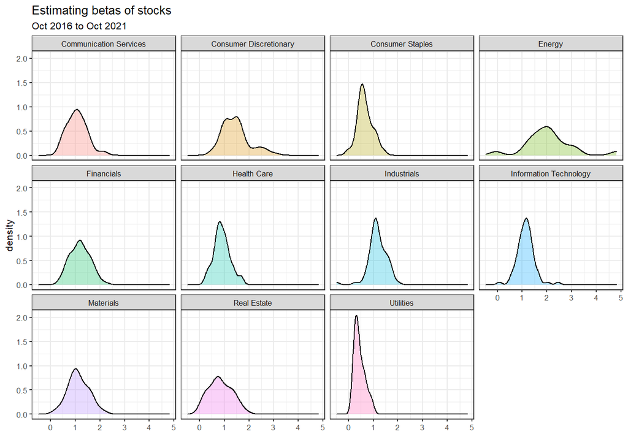

```r
# plot betas
ggplot(data = capm_results, aes(x = beta, fill=sector))+
  geom_density(alpha = 0.3)+
  theme_bw(8)+
  labs(title = 'Estimating betas of stocks',
       subtitle = paste0(zoo::as.yearmon(starting_date), " to ", zoo::as.yearmon(ending_date)),
       x = "") +
  facet_wrap(~sector)+
  theme(legend.position = "none")+
  NULL
```

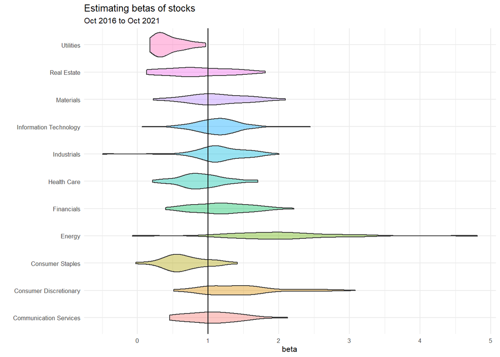

```r
ggplot(data = capm_results, aes(x = sector, y=beta, fill=sector))+
  geom_violin(alpha = 0.4)+
  theme_minimal(8)+
  labs(title = 'Estimating betas of stocks',
       subtitle = paste0(zoo::as.yearmon(starting_date), " to ", zoo::as.yearmon(ending_date)),
       x = "") +
  coord_flip()+
  theme(legend.position = "none")+
  geom_hline(yintercept = 1)+
  NULL
```

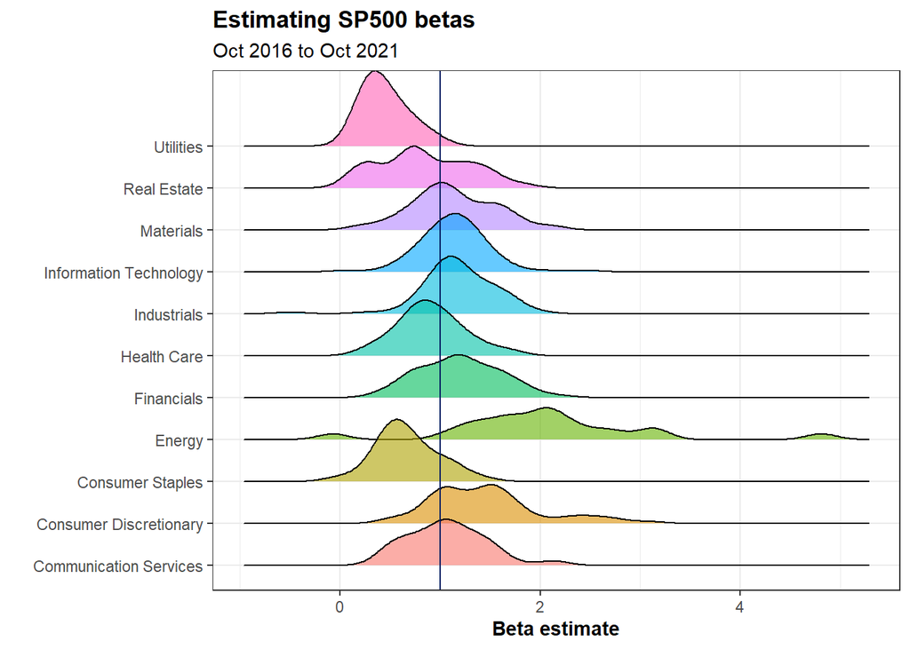

```r
ggplot(capm_results, aes(x = beta, y = sector, fill=sector)) +
  geom_density_ridges(alpha= 0.6) +
  theme_bw() +
  labs(
    x = "Beta estimate",
    y = "",
    title = "Estimating SP500 betas",
    subtitle = paste0(zoo::as.yearmon(starting_date), " to ", zoo::as.yearmon(ending_date)),
  ) +
  theme(
    axis.title = element_text(face = "bold"),
    plot.title = element_text(face = "bold"),
    legend.position = "none"
  )+
  geom_vline(xintercept = 1, colour = "#001e62")+
  NULL
```

```r
capm_results %>%
  arrange(desc(beta)) %>%
  kable()%>%
  kable_styling(bootstrap_options = c("striped", "hover", "condensed"))
```

| symbol | security | beta | se_beta | beta_low | beta_high | alpha | r.squared | residual_se | sector | gics_sub_industry | headquarters_location |
| --- | --- | --- | --- | --- | --- | --- | --- | --- | --- | --- | --- |
| APA | APA Corporation | 4.809 | 0.781 | 3.247 | 6.371 | -0.040 | 0.392 | 0.261 | Energy | Oil & Gas Exploration & Production | Houston, Texas |
| DVN | Devon Energy | 3.161 | 0.417 | 2.327 | 3.995 | -0.025 | 0.494 | 0.139 | Energy | Oil & Gas Exploration & Production | Oklahoma City, Oklahoma |
| MRO | Marathon Oil | 3.109 | 0.467 | 2.175 | 4.043 | -0.023 | 0.429 | 0.156 | Energy | Oil & Gas Exploration & Production | Houston, Texas |
| CZR | Caesars Entertainment | 3.083 | 0.466 | 2.151 | 4.014 | 0.015 | 0.426 | 0.156 | Consumer Discretionary | Casinos & Gaming | Reno, Nevada |
| HAL | Halliburton | 2.762 | 0.314 | 2.134 | 3.390 | -0.034 | 0.568 | 0.105 | Energy | Oil & Gas Equipment & Services | Houston, Texas |
| NCLH | Norwegian Cruise Line Holdings | 2.738 | 0.330 | 2.078 | 3.398 | -0.027 | 0.539 | 0.110 | Consumer Discretionary | Hotels, Resorts & Cruise Lines | Miami, Florida |
| RCL | Royal Caribbean Group | 2.708 | 0.326 | 2.057 | 3.360 | -0.019 | 0.540 | 0.109 | Consumer Discretionary | Hotels, Resorts & Cruise Lines | Miami, Florida |
| FANG | Diamondback Energy | 2.591 | 0.389 | 1.814 | 3.369 | -0.019 | 0.430 | 0.130 | Energy | Oil & Gas Exploration & Production | Midland, Texas |
| PENN | Penn National Gaming | 2.585 | 0.505 | 1.576 | 3.595 | 0.010 | 0.308 | 0.169 | Consumer Discretionary | Casinos & Gaming | Wyomissing, Pennsylvania |
| WYNN | Wynn Resorts | 2.454 | 0.321 | 1.812 | 3.097 | -0.024 | 0.498 | 0.107 | Consumer Discretionary | Casinos & Gaming | Paradise, Nevada |
| DXC | DXC Technology | 2.447 | 0.319 | 1.809 | 3.085 | -0.025 | 0.499 | 0.107 | Information Technology | IT Consulting & Other Services | Tysons Corner, Virginia |
| MGM | MGM Resorts International | 2.391 | 0.280 | 1.830 | 2.951 | -0.014 | 0.552 | 0.094 | Consumer Discretionary | Casinos & Gaming | Paradise, Nevada |
| PVH | PVH | 2.333 | 0.255 | 1.823 | 2.843 | -0.024 | 0.587 | 0.085 | Consumer Discretionary | Apparel, Accessories & Luxury Goods | New York City, New York |
| OXY | Occidental Petroleum | 2.327 | 0.453 | 1.421 | 3.232 | -0.026 | 0.309 | 0.151 | Energy | Oil & Gas Exploration & Production | Houston, Texas |
| SLB | Schlumberger | 2.317 | 0.252 | 1.813 | 2.822 | -0.036 | 0.589 | 0.084 | Energy | Oil & Gas Equipment & Services | Curaçao, Kingdom of the Netherlands |
| CCL | Carnival Corporation | 2.232 | 0.320 | 1.592 | 2.871 | -0.028 | 0.453 | 0.107 | Consumer Discretionary | Hotels, Resorts & Cruise Lines | Miami, Florida |
| LNC | Lincoln National | 2.214 | 0.245 | 1.724 | 2.703 | -0.015 | 0.581 | 0.082 | Financials | Multi-line Insurance | Radnor, Pennsylvania |
| MPC | Marathon Petroleum | 2.130 | 0.273 | 1.584 | 2.676 | -0.011 | 0.508 | 0.091 | Energy | Oil & Gas Refining & Marketing | Findlay, Ohio |
| DISH | Dish Network | 2.127 | 0.258 | 1.610 | 2.644 | -0.025 | 0.535 | 0.086 | Communication Services | Cable & Satellite | Meridian, Colorado |
| FCX | Freeport-McMoRan | 2.095 | 0.364 | 1.366 | 2.824 | 0.001 | 0.359 | 0.122 | Materials | Copper | Phoenix, Arizona |
| VLO | Valero Energy | 2.093 | 0.304 | 1.485 | 2.701 | -0.012 | 0.446 | 0.102 | Energy | Oil & Gas Refining & Marketing | San Antonio, Texas |
| HES | Hess Corporation | 2.075 | 0.311 | 1.453 | 2.697 | -0.011 | 0.430 | 0.104 | Energy | Integrated Oil & Gas | New York City, New York |
| APTV | Aptiv | 2.069 | 0.221 | 1.628 | 2.511 | -0.005 | 0.598 | 0.074 | Consumer Discretionary | Auto Parts & Equipment | Dublin, Ireland |
| EOG | EOG Resources | 2.028 | 0.280 | 1.467 | 2.589 | -0.020 | 0.470 | 0.094 | Energy | Oil & Gas Exploration & Production | Houston, Texas |
| AMD | Advanced Micro Devices | 2.025 | 0.398 | 1.229 | 2.821 | 0.029 | 0.305 | 0.133 | Information Technology | Semiconductors | Santa Clara, California |
| URI | United Rentals | 2.006 | 0.263 | 1.480 | 2.531 | 0.004 | 0.497 | 0.088 | Industrials | Trading Companies & Distributors | Stamford, Connecticut |
| OKE | Oneok | 1.963 | 0.296 | 1.371 | 2.555 | -0.007 | 0.428 | 0.099 | Energy | Oil & Gas Storage & Transportation | Tulsa, Oklahoma |
| SIVB | SVB Financial | 1.959 | 0.257 | 1.446 | 2.473 | 0.008 | 0.497 | 0.086 | Financials | Regional Banks | Santa Clara, California |
| C | Citigroup | 1.900 | 0.178 | 1.544 | 2.256 | -0.013 | 0.659 | 0.060 | Financials | Diversified Banks | New York City, New York |
| TSLA | Tesla | 1.880 | 0.513 | 0.853 | 2.907 | 0.039 | 0.185 | 0.172 | Consumer Discretionary | Automobile Manufacturers | Palo Alto, California |

[output cut: 472 more lines]

```r
# save file with stock data, that you could read using vroom::vroom()
# write_csv(sp500_stocks, "data/sp500_stocks.csv")
```